# Podstawowe operacje w R

Katarzyna Rumińska

Opublikowano wt. paź 25 22:13:21 2022

## 0.1 Rodzaje struktur danych

### 0.1.1 Wektory

**Zadanie 1**. Utwórz wektor danych “wiek” (w latach). Każdy z nich ma mieć 10 obserwacji, dowolne wartości. + ryzyko

```r
wiek <- c(5,12,13,24,28,32,35,43,57,68)
ryzyko <- c(0,1,0,0,1,1,0,1,1,1)
```

### 0.1.2 Czynnik

**Zadanie 2**. Utwórz wektor ryzyko jako czynnik (factor): dla wieku >30 lat “0” o etykiecie “wysokie”, a dla pozostałych “1” o etykiecie “niskie”. Wskazówka: można wykorzystać ifelse.

```r
ryzyko<-as.factor(ifelse(wiek>30,0,1))
kody<-c(wysokie=0,niskie=1)
ryzyko<-factor(ryzyko,levels=kody, labels=names(kody))
levels(ryzyko)
```

```
## [1] "wysokie" "niskie"
```

### 0.1.3 Ramka danych

```r
ramka<-data.frame(wiek,ryzyko)
ramka<-ramka[order(wiek),]
ramka
```

```
##    wiek  ryzyko
## 1     5  niskie
## 2    12  niskie
## 3    13  niskie
## 4    24  niskie
## 5    28  niskie
## 6    32 wysokie
## 7    35 wysokie
## 8    43 wysokie
## 9    57 wysokie
## 10   68 wysokie
```

### 0.1.4 Tablice

**Zadanie 4**. Utwórz tablicę “tablica” z wieku i ryzyka o wymiarach 5 wierszy, 2 kolumny (zmienne), 2 podgrupy o nazwie “Grupa 1.” oraz “Grupa 2”.

```r
tablica1<- array(c(wiek[1:5], ryzyko[1:5]), dim=c(5,2))
tablica2 <- array(c(wiek[6:10],ryzyko[6:10]),dim=c(5,2))
tablica<- array(c(tablica1,tablica2),dim=c(5,2,2))
dimnames(tablica)[[2]]<- list("Wiek","Ryzyko")
dimnames(tablica)[[3]]<- list("Grupa 1","Grupa 2")
tablica
```

```
## , , Grupa 1
##
##      Wiek Ryzyko
## [1,]    5      2
## [2,]   12      2
## [3,]   13      2
## [4,]   24      2
## [5,]   28      2
##
## , , Grupa 2
##
##      Wiek Ryzyko
## [1,]   32      1
## [2,]   35      1
## [3,]   43      1
## [4,]   57      1
## [5,]   68      1
```

### 0.1.5 Listy

**Zadanie 5**. Utwórz listę “lista” zawierającą pierwsze 3 elementy każdej z grup w tablicy “tablica” oraz 3 kolory które najbardziej lubisz.

```r
lista<-list(tablica1[1:3,1:2],tablica2[1:3,1:2],c("fioletowy", "niebieski", "różowy"))
lista
```

```
## [[1]]
##      [,1] [,2]
## [1,]    5    2
## [2,]   12    2
## [3,]   13    2
##
## [[2]]
##      [,1] [,2]
## [1,]   32    1
## [2,]   35    1
## [3,]   43    1
##
## [[3]]
## [1] "fioletowy" "niebieski" "różowy"
```

### 0.1.6 Macierze

**Zadanie 6**. Utwórz macierz kwadratową B z cyfr od 1 do 9; macierz kwadratową A 2x3 z cyfr od 1 do 6; macierz C 3x2 z cyfr od 1 do 6. Dodaj do macierzy A wiersz [1,1,1] jako macierz D oraz do macierzy C kolumnę [1,1,1] jako macierz E. Wyświetl tylko trzeci wiersz macierzy E i trzecią kolumnę macierzy D.

```r
B<-matrix(c(1:9), nrow = 3, ncol = 3)
A<-matrix(c(1:6), nrow = 2, ncol = 3)
C<-matrix(c(1:6), nrow = 3, ncol = 2)
D<-rbind(A,c(1,1,1))
E<-cbind(C,c(1,1,1))
E[3,]
```

```
## [1] 3 6 1
```

```r
D[,3]
```

```
## [1] 5 6 1
```

## 0.2 Analiza opisowa

**Zadanie 7**. Dokonaj pełnej analizy opisowej dla osób z grupy 1. oraz grupy 2. (średnia, odchylenia, kwartyle, skośność, kurtoza).

```r
#I sposob
library(e1071)
Statystyki_opisowe_Tabela1 <- array(c(mean(tablica1[,1]),sd(tablica1[,1]),quantile(tablica1[,1],c(0.25,0.75)),skewness(tablica1[,1]),kurtosis(tablica1[,1])))
Statystyki_opisowe_Tabela2 <- array(c(mean(tablica2[,1]),sd(tablica2[,1]),quantile(tablica2[,1],c(0.25,0.75)),skewness(tablica2[,1]),kurtosis(tablica2[,1])))
Statystyki_opisowe_Tabela1
```

```
## [1] 16.4000000  9.3968080 12.0000000 24.0000000  0.0949312 -2.0036885
```

```r
Statystyki_opisowe_Tabela2
```

```
## [1] 47.000000 15.215124 35.000000 57.000000  0.289243 -1.969635
```

```r
Statystki_opisowe <- array(rbind(Statystyki_opisowe_Tabela1,Statystyki_opisowe_Tabela2),dim=c(2,6,1))
dimnames(Statystki_opisowe)[[1]]<- list("Grupa 1","Grupa 2")
dimnames(Statystki_opisowe)[[2]]<- list("Średnia","Odchylenie","Kwartyl 1-rzędu","Kwartyl 3-rzędu","Skośność", "Kurtoza")
dimnames(Statystki_opisowe)[[3]]<- list("Statystyki opisowe dla zmiennej wiek w poszczególnych podgrupach")
Statystki_opisowe
```

```
## , , Statystyki opisowe dla zmiennej wiek w poszczególnych podgrupach
##
##         Średnia Odchylenie Kwartyl 1-rzędu Kwartyl 3-rzędu  Skośność  Kurtoza
## Grupa 1    16.4    9.39681              12              24 0.0949312 -2.00369
## Grupa 2    47.0   15.21512              35              57 0.2892427 -1.96963
```

```r
#II sposob
BD<-array(c(mean(tablica[,1,1]),
sd(tablica[,1,1]),
quantile(tablica[,1,1],c(0.25,0.75)),
skewness(tablica[,1,1]),
kurtosis(tablica[,1,1])))

array(c(mean(tablica[,1,2]),
sd(tablica[,1,2]),
quantile(tablica[,1,2],c(0.25,0.75)),
skewness(tablica[,1,2]),
kurtosis(tablica[,1,2])))
```

```
## [1] 47.000000 15.215124 35.000000 57.000000  0.289243 -1.969635
```

**Zadanie 8**. Przedstaw na histogramach oraz wykresach ramkowych rozkłady wieku osób z wysokim i niskim ryzykiem kredytowym (porównanie - 2 wykresy obok siebie).

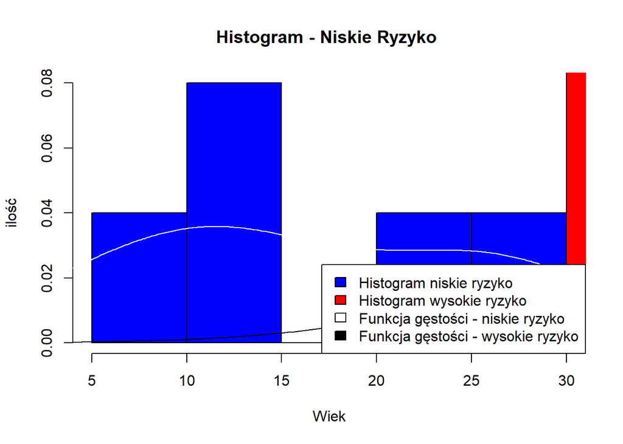

```r
#histogram
hist(ramka[ryzyko=="niskie",1], col= "blue", prob = TRUE, main="Histogram - Niskie Ryzyko ",xlab="Wiek", ylab="ilość")
hist(ramka[ryzyko=="wysokie",1], col= "red", add = TRUE)
lines(density(ramka[ryzyko=="niskie",1]), col = "white")
lines(density(ramka[ryzyko=="wysokie",1]), col = "black")
legend("bottomright", c("Histogram niskie ryzyko","Histogram wysokie ryzyko", "Funkcja gęstości - niskie ryzyko", "Funkcja gęstości - wysokie ryzyko"), bty = "o", fill=c("blue", "red", "white","black"))
```

```r
?hist
```

```
## uruchamianie serwera httpd dla pomocy ... wykonano
```

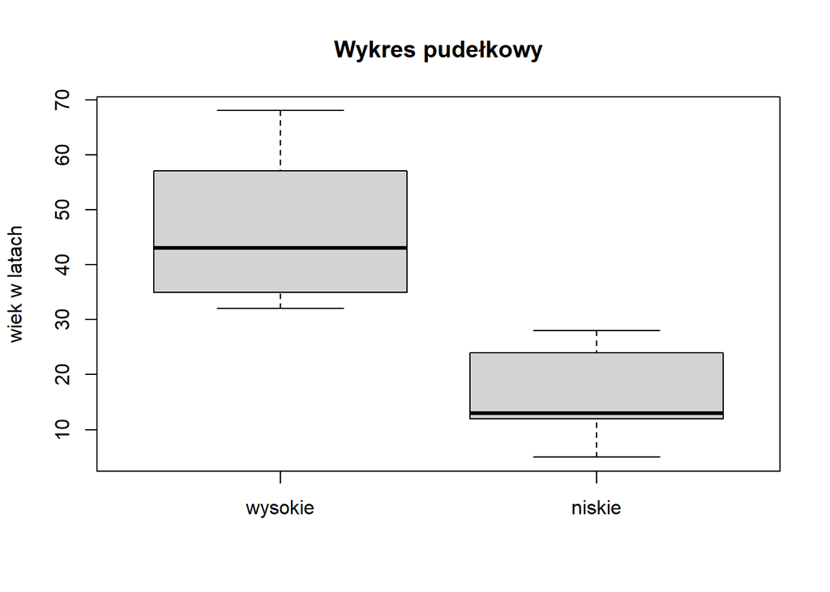

```r
#Wykres pudełkowy
boxplot(ramka$wiek~ramka$ryzyko, main = "Wykres pudełkowy", ylab = "wiek w latach", xlab = "")
```

## 0.3 Fajki

### 0.3.1 Fajka bazowa

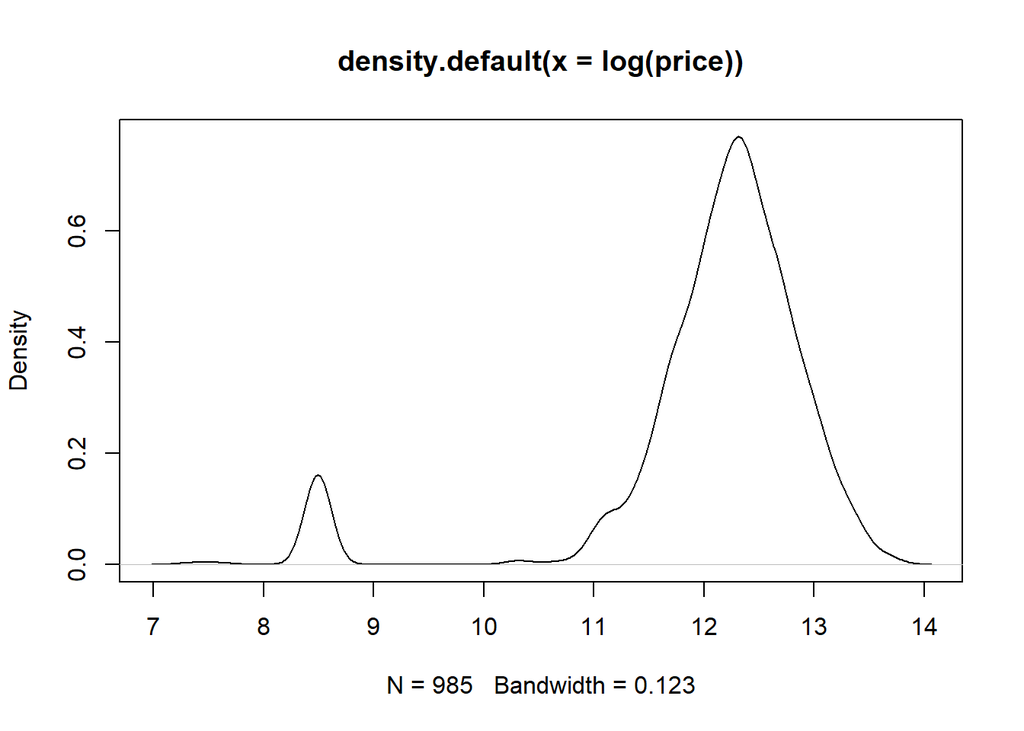

```r
price |>
  log() |>
  density() |>
  plot()
```

### 0.3.2 Fajka %>%

**Przykład**. Wykreśl histogram cen sprzedaży mieszkań (“Condo”) z dwiema sypialniami.

Filtry z dplyr działają na całej ramce danych, stąd by wykreślić ceny musimy użyć pakietu ggplot2:

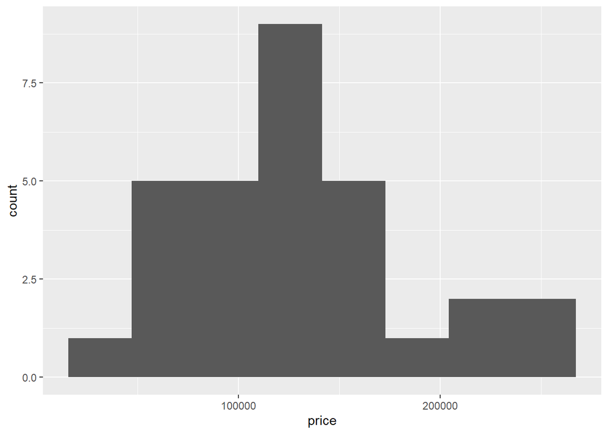

Bez użycia filtra i fajek nie ma takiej potrzeby:

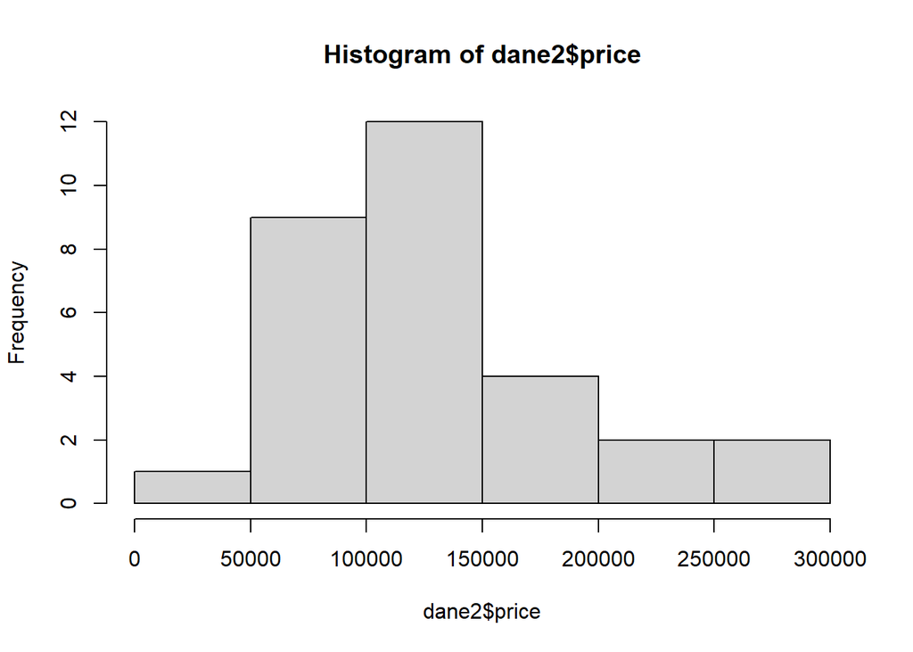